# Session 4: Plotting

Published

4 June 2025

Modified

4 June 2025

### This session will cover:

- Introduction to grammar of graphics and the `{ggplot2}` package
- Basic plots: scatter plots, bar charts, histograms, lines
- Customizing plots: themes, labels, and colours
- Saving and exporting plots

## Setup

We will only need one new package for today, the `{afcharts}` package by the Government Analysis Function. It can be installed as follows:

```r
# install the Government Analysis Function's {ggplot2} theme package
install.packages("afcharts")
```

We will load in the following packages for today’s session. We have seen most of these packages before.

```r
library(afcharts)
library(dplyr)
library(ggplot2)
library(janitor)
library(jsonlite)
library(readr)
library(readxl)
library(tidyr)
```

We will use the cereals, GDP deflators and MMO vessels data that we have used previously.

```r
# Cereals data and transform it into tidy data
cereals_df <- read_csv("data/cereals.csv", name_repair = make_clean_names) |>
  pivot_longer(
    cols = -year,
    names_to = "cereal",
    values_to = "yield",
    values_drop_na = TRUE
  )

# UK GDP deflators series
gdp_deflators_df <- read_json("data/gdp-deflators.json", simplifyVector = TRUE)

# MMO vessel list
vessels_df <- read_xlsx("data/May_2025_Over_10m_vessel_list.xlsx", skip = 4, .name_repair = make_clean_names)
```

## Plotting in R

One of the main features and advantages of R is the ease at which to create data visualisations with is its built-in graphics capabilities. Base R has a number of plot types available as follows:

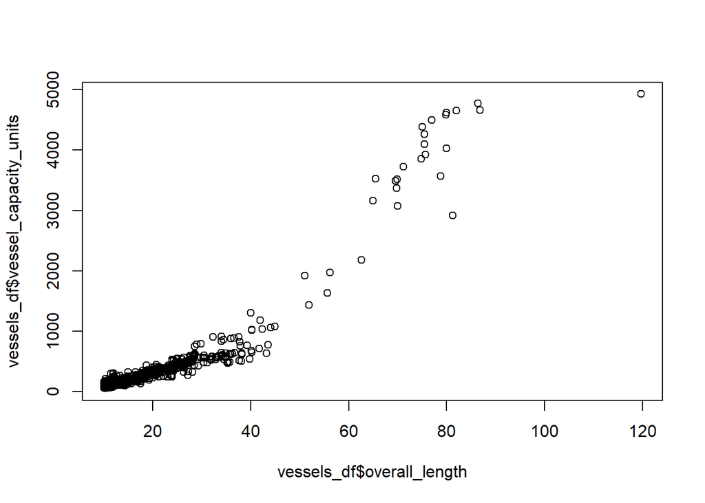

```r
# scatter plot
plot(x = vessels_df$overall_length, y = vessels_df$vessel_capacity_units)
```

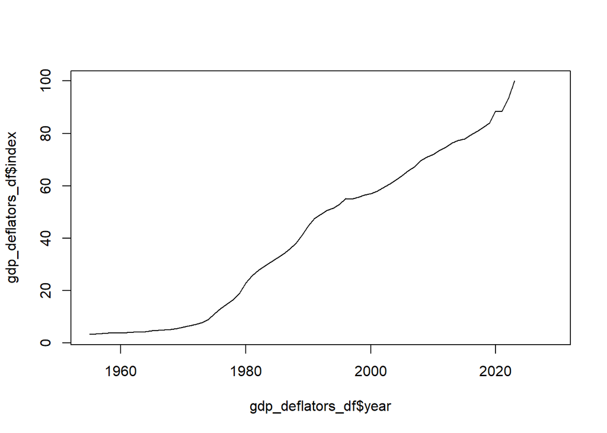

```r
# line plot
plot(x = gdp_deflators_df$year, y = gdp_deflators_df$index, type = "l")
```

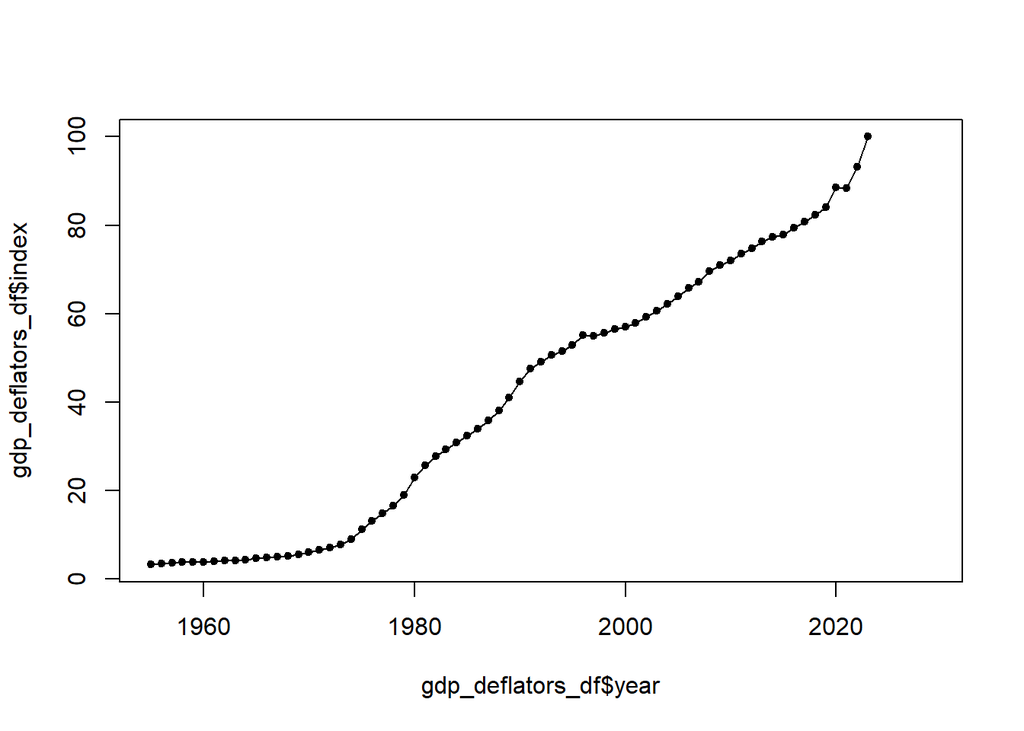

```r
# line and point plot
plot(x = gdp_deflators_df$year, y = gdp_deflators_df$index, type = "o", pch = 20)
```

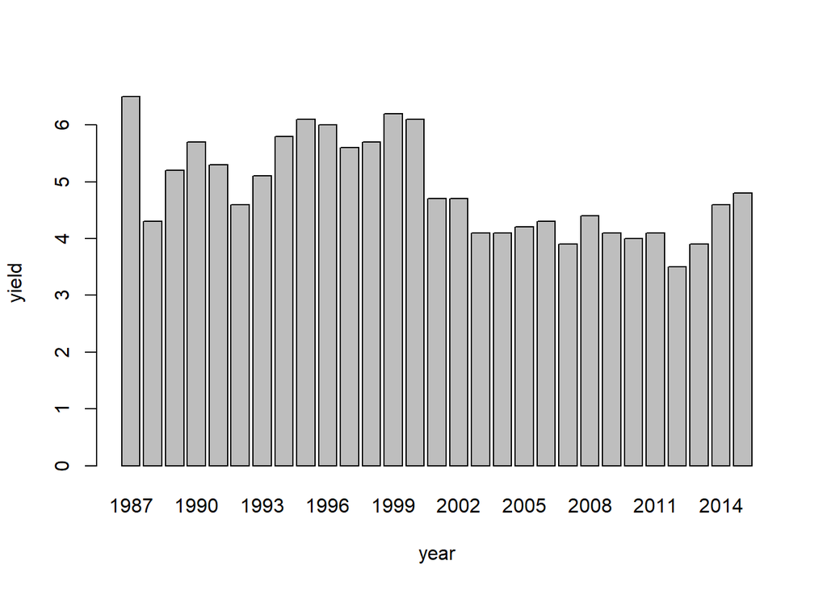

```r
# bar plot
barplot(yield ~ year, data = cereals_df[cereals_df$cereal == "triticale",])
```

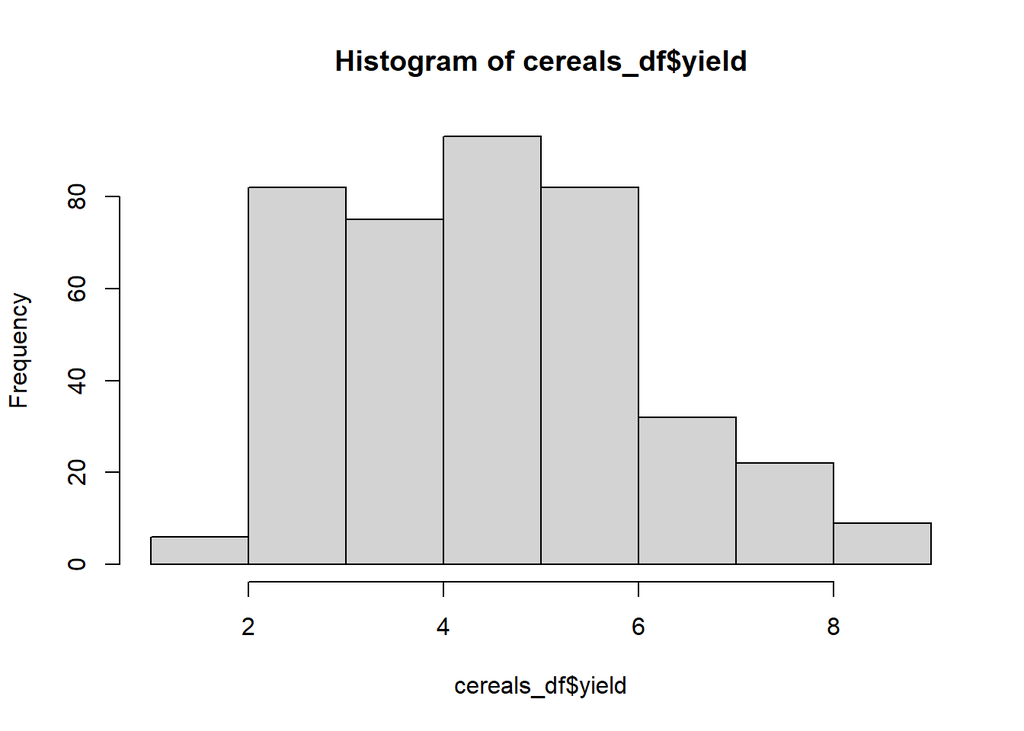

```r
# histogram
hist(cereals_df$yield)
```

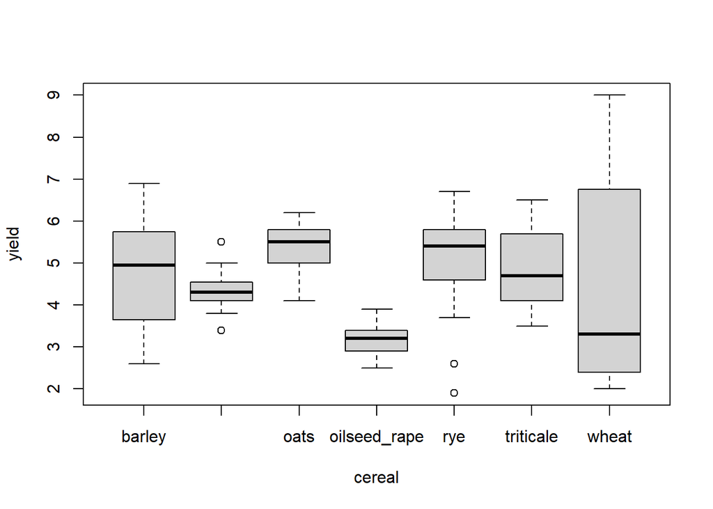

```r
# boxplot
boxplot(yield ~ cereal, data = cereals_df)
```

Whilst very easy to create such plots, there is a inconsistency across plotting function as to how arguments are specified. To make a more intricate plot is not straight forward. Therefore we will use the tidyverse plotting package `{ggplot2}`.

## Grammar of Graphics and `{ggplot2}`

The Grammar of Graphics is a framework for data visualization that dissects each component of a graph into individual components. This framework was introduced by Leland Wilkinson in his 1999 book [*The Grammar of Graphics*](https://link.springer.com/book/10.1007/0-387-28695-0) and provides the theoretical underpinnings of the [`{ggplot2}`](https://ggplot2.tidyverse.org/) package.

The idea is to breakdown a graphic into a set of independent components that can be combined in a systematic way. Here are an explanation the key components:

- **Data** - the data to be visualised. For `{ggplot2}` this should be in a **tidy** format.
- **Aesthetics** or **Mappings** - the visual properties that represent data, such as position (x, y), colour, fill, linetype, size, shape, *etc*.
- **Geometries** - the type of plot or shape used to represent the data, like points, lines, bars, *etc*.
- **Statistics** - statistical transformations applied to the data.
- **Scales** - maps data values to aesthetic values (*e.g.* a numeric variable to a colour gradient).
- **Facets** - subplots that split the data into subsets based on one or more variables.
- **Coordinates** - the coordinate system used (*e.g.* Cartesian, polar).
- **Themes** - controls the non-data elements of the plot like background, grid lines, and fonts.